# Probabilidad y Estadística Fundamental

Clase 2: Tablas de frecuencia y gráficos

Departamento de Estadı́stica, Sede Bogotá

## Contenido

### Presentación tabular

- Tabla de frecuencias.
- Elementos: $f_i$, $F_i$, $h_i$, $H_i$, %.
- Pasos para construirla.

### Ejemplos prácticos

- Variable cuantitativa discreta.
- Variable cualitativa nominal.
- Variable cuantitativa continua.

### Presentación gráfica

- Gráfico de barras.
- Histograma.
- Polígono de frecuencias.
- Gráfico circular y de líneas.

### Tipos de distribuciones

- Distribución simétrica.
- Asimétrica positiva y negativa.

### Estadística descriptiva de una variable

La estadística descriptiva de una variable es el **conjunto de métodos y técnicas** que permiten **organizar, resumir y describir los datos** obtenidos de una sola característica o variable, con el fin de facilitar su interpretación.

## Las técnicas y métodos mas utilizados son:

- Tablas de frecuencias.
- Gráficos (barras, histogramas, gráficos circulares y otros).
- Medidas estadísticas como la media, mediana, moda, varianza y desviación estándar.

#### Su objetivo principal es:

- **Presentar** la información de manera **clara y comprensible**, sin realizar inferencias o conclusiones más allá de los datos analizados.

## Presentación tabular y gráfica

- Permiten describir la **distribución de una variable**
- Se puede expresar en:
  - Cantidades
  - Proporciones
  - Porcentajes
- Se aplican a:
  - Variables categóricas
  - Variables numéricas

[figure not shown]

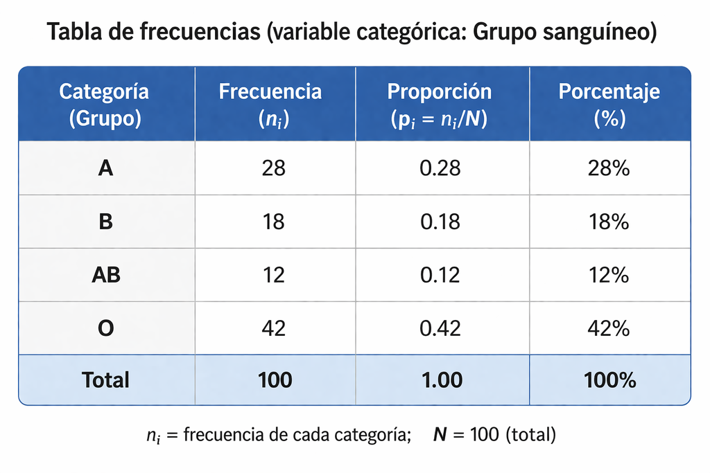

## Presentación tabular

## **Tabla de frecuencias**

- Representación tabular de los datos de una variable
- Muestra la frecuencia de cada valor o intervalo
- Organiza grandes cantidades de información
- Permite identificar patrones o tendencias
- Permite analizar el comportamiento de los datos

### **Elementos principales de una tabla de frecuencias**

- **Datos o clases:** valores individuales o intervalos.
- **Frecuencia absoluta ($f_i$):** número de veces que aparece un dato.
- **Frecuencia acumulada ($F_i$):** suma progresiva de las frecuencias absolutas.
- **Frecuencia relativa ($h_i$):** proporción o porcentaje respecto al total.
- **Frecuencia relativa acumulada ($H_i$):** suma progresiva de las frecuencias relativas.

## Pasos para construir una tabla de frecuencias

- 1. Determinar el número de clases o intervalos.
- 2. Hallar el rango.
- 3. Determinar la amplitud del intervalo.
- 4. Armar los intervalos
- 5. Ubicar las frecuencias en los intervalos.
- 6. Llenar la tabla de frecuencias.

## 1. Determinar el número de clases o intervalos

Los datos pueden agruparse en el numero de clases o intervalos que se desee; sin embargo es recomendable utilizar criterios como la **raíz cuadrada del tamaño de la muestra** o la **formula de Sturges** para definir una cantidad apropiada de intervalos.

- **Formulas para determinar el numero de clases:**
- $k=\sqrt{n}$, donde $k$ es el numero de clases y $n$ es el tamaño de la muestra o numero de datos.
- $k=1+3.3322\log_{10}(n)$, donde $k$ es el numero de clases y $n$ es el tamaño de la muestra o numero de datos.

*Un numero razonable de clases puede ser entre 5 y 20 clases, si el resultado al aplicar las formulas da un numero decimal se redondea al entero mayor mas cercano.*

## 2. Hallar el rango

Después de que se tenga el numero de clases establecido, se procede a hallar el máximo y mínimo de los datos, para hallar el rango.

El rango se calcula como:
$$𝑅𝑎𝑛𝑔𝑜:𝑅=𝑀𝑎𝑥𝑖𝑚𝑜−M𝑖𝑛𝑖𝑚𝑜$$

## 3. Determinar la amplitud del intervalo

$$Amplitud: A= \frac{R}{k}$$

- Determinar el ancho de cada intervalo o clase,
- Definir dónde se agrupan las frecuencias en la tabla.
- Generalmente se usan intervalos de igual longitud.
- Puede redondearse para facilitar la interpretación.

## 4. Armar los intervalos

[figure not shown]

## Ubicar y registrar las frecuencias

## Ubicar las frecuencias

- Se cuentan los datos que pertenecen a cada intervalo.
- Ese conteo determina la frecuencia de cada clase.

## Llenar la tabla de frecuencias

- Se registran las frecuencias en la tabla.
- Se completa cada elemento correspondiente.

## Elementos de la tabla de frecuencias

1. **Marca de clase $𝑥_𝑖$:**
   - Es el punto medio del intervalo.
   - Se calcula como la suma del valor mínimo mas el valor máximo de la clase,
   - El resultado se divide por 2.
2. **Frecuencia absoluta $𝑓_𝑖$:** es la cantidad de veces que un dato pertenece a un intervalo o una clase.
3. **Frecuencia acumulada $𝐹_𝑖$:** es la suma progresiva de las frecuencias absolutas desde el primer valor o clase hasta el ultimo.
   - En el ultimo intervalo tiene que dar el numero total de datos.

## Elementos de la tabla de frecuencias

4. **Frecuencia relativa $ℎ_𝑖$:** proporción o fracción que representa nro de veces que aparece un valor con respecto al total de datos.
   - Se obtiene dividiendo la frecuencia absoluta $f_i$ entre el número total de datos $n$.
5. **Frecuencia relativa acumulada $𝐻_𝑖$:** es la suma progresiva de las frecuencias relativas desde el primer valor hasta el ultimo.
- En el ultimo intervalo tiene que dar 1.
6. **Porcentaje %:** se calcula como la frecuencia relativa multiplicada por 100%.
7. **% acumulado:** es la suma progresiva de los porcentajes en cada intervalo.
- En el ultimo intervalo tiene que dar el 100%.

## Ejemplo 1

#### Variable cuantitativa discreta:

Se entrevistan 1.000 familias de la Ciudad de Buenos Aires, para saber cuántos hijos tiene cada familia. Los datos son: 0, 0, 3, 1, 1, 1, 2, 2, 2, 3, 1, 1, 2, 0, 0, 0, 2, 1, 8, 1, 1, 2, 3,… Donde cada número es la cantidad de hijos de cada una de las familias entrevistadas.

## Resultados

Debido a que la muestra es grande, es necesario resumir la información:

| Número de hijos | Número de familias |
| --- | --- |
| 0 | 250 |
| 1 | 200 |
| 2 | 300 |
| 3 | 160 |
| 4 | 50 |
| 5 | 20 |
| 6 | 10 |
| 7 | 7 |
| 8 | 2 |
| 9 | 1 |

- En este caso **no es necesario** determinar el número de clases o intervalos, ya que la variable es **cuantitativa discreta** y los datos se pueden agrupar por su valor individual.
- Aplicando los pasos para construir la tabla de frecuencias, se obtiene la siguiente tabla:

| Nro. Hijos | \(f_{i}\) | \(F_{i}\) | \(h_{i}\) | \(H_{i}\) | % | % Acum |
| --- | --- | --- | --- | --- | --- | --- |
| 0 | 250 | 250 | 0.250 | 0.25 | 25.0 | 25 |
| 1 | 200 | 450 | 0.200 | 0.45 | 20.0 | 45 |
| 2 | 300 | 750 | 0.300 | 0.75 | 30.0 | 75 |
| 3 | 160 | 910 | 0.160 | 0.91 | 16.0 | 91 |
| 4 | 50 | 960 | 0.050 | 0.96 | 5.0 | 96 |
| 5 | 20 | 980 | 0.020 | 0.98 | 2.0 | 98 |
| 6 | 10 | 990 | 0.010 | 0.99 | 1.0 | 99 |
| 7 | 7 | 997 | 0.007 | 0.997 | 0.7 | 99.7 |
| 8 | 2 | 999 | 0.002 | 0.999 | 0.2 | 99.9 |
| 9 | 1 | 1000 | 0.001 | 1 | 0.1 | 100 |
| Total | 1000 |  | 1.000 |  | 100.0 |  |

## Hallazgos

- El número de hijos más común es 2, con una frecuencia absoluta de 300 familias, lo que representa el 30% de la muestra, seguido por 0 hijos con 250 familias (25%) y 1 hijo con 200 familias (20%).
- Sumando los primeros 4 primeros porcentajes, se obtiene que el 91% de las familias tienen entre 0 y 3 hijos y el 9% restante tienen entre 4 y 9 hijos.
- Segun el estudio pocas familias tienen 4 o más hijos, lo que puede indicar una tendencia hacia familias más pequeñas en la Ciudad de Buenos Aires.

## Ejemplo 2

#### Variable cualitativa nominal:

Se hizo una encuesta a 200 estudiantes de la universidad nacional para conocer cual color de ojos era el mas predominante. Los resultados fueron los siguientes:

- Café: 90
- Negro: 60
- Azul: 25
- Verde: 15
- Miel:10

## Tabla de frecuencias

- En este caso no es necesario determinar el número de clases o intervalos, ya que la variable es cualitativa nominal y los datos se pueden agrupar por categorías.
- Aplicando los pasos para construir la tabla de frecuencias, se obtiene la siguiente tabla:

| Color | \(f_{i}\) | \(F_{i}\) | \(h_{i}\) | \(H_{i}\) | % | % Acum |
| --- | --- | --- | --- | --- | --- | --- |
| Café | 90 | 90 | 0.450 | 0.450 | 45% | 45% |
| Negro | 60 | 150 | 0.300 | 0.750 | 30% | 75% |
| Azul | 25 | 175 | 0.125 | 0.875 | 12.5% | 87.5% |
| Verde | 15 | 190 | 0.075 | 0.950 | 7.5% | 95% |
| Miel | 10 | 200 | 0.050 | 1.000 | 5% | 100% |
| Total | 200 |  | 1.000 |  | 100% |  |

## Hallazgos

- El color de ojos más común entre los estudiantes encuestados es el café, con una frecuencia absoluta de 90 estudiantes, lo que representa el 45% de la muestra, seguido por el color negro con 60 estudiantes (30%), el azul con 25 estudiantes (12.5%), el verde con 15 estudiantes (7.5%) y el miel con 10 estudiantes (5%).
- Los colores de ojos que mas predominaron fueron el café y el negro, con una participación del 75% en total.

## Ejemplo 3

#### Variable cuantitativa continua:

Los siguientes datos corresponden a las precios unitarios (en miles de pesos) de 100 productos observados en un ejercicio simulado. Los precios son datos continuos, ya que su valor se mide y puede tomar cualquier valor dentro de un intervalo: 60, 60.5, 61, 61, 61.5, 63.5, 63.5, 63.5, 64, 64, 64, 64….

Para organizar y resumir esta información, se procede a construir una tabla de frecuencias agrupando las alturas en intervalos, para eso se determina:

- el número de clases,
- el rango,
- la amplitud del intervalo,
- se arman los intervalos,
- se ubican las frecuencias en cada intervalo,
- se llena la tabla de frecuencias.

## Pasos para construir la tabla de frecuencias

1. Determinar el número de clases o intervalos. En el caso de este ejemplo, $𝑛=100$:
   $$k=\sqrt{100}=10$$
   $$k=1+3.3322\log_{10}(100)=7.644≈8$$
   Tomaremos 8 intervalos para este ejemplo, por lo tanto $k=8$.
2. Hallar el rango, el valor mínimo es 60 y el valor máximo es 74, por lo tanto el rango se calcula como:
   $$𝑅𝑎𝑛𝑔𝑜: R = 74 - 60 = 14$$

## Pasos para construir la tabla de frecuencias

3. Determinar la amplitud del intervalo. La amplitud se calcula como:
   $$A = \frac{R}{k} = \frac{14}{8} = 1.75$$
   Redondeando a un número más conveniente, se puede tomar una amplitud de 2 mil pesos.
4. Armar los intervalos.
   - El primer intervalo se establece desde el mínimo (60 mil pesos) hasta el mínimo más la amplitud (62 mil pesos), es decir, [60, 62).
   - El segundo intervalo será [62, 64), el tercero [64, 66), el cuarto [66, 68), el quinto [68, 70), el sexto [70, 72), el séptimo [72, 74) y el octavo [74, 76).

## Pasos para construir la tabla de frecuencias

5. Ubicar las frecuencias en los intervalos.
   - Se cuenta cuántos precios caen dentro de cada intervalo,
   - se registra esa cantidad como la frecuencia absoluta $f_i$ para cada intervalo.
6. Llenar la tabla de frecuencias.
   - Se completa la tabla de frecuencias con los elementos correspondientes (marca de clase, frecuencia absoluta, frecuencia acumulada, frecuencia relativa, etc.).

## Tabla de Frecuencias

Haciendo todos los cálculos la tabla de frecuencias queda de la siguiente forma:

| Intervalo | \(x_{i}\) | \(f_{i}\) | \(F_{i}\) | \(h_{i}\) | \(H_{i}\) | % | % Acum |
| --- | --- | --- | --- | --- | --- | --- | --- |
| [60-62) | 61 | 5 | 5 | 0.05 | 0.05 | 5% | 5% |
| [62-64) | 63 | 3 | 8 | 0.03 | 0.08 | 3% | 8% |
| [64-66) | 65 | 15 | 23 | 0.15 | 0.23 | 15% | 23% |
| [66-68) | 67 | 40 | 63 | 0.40 | 0.63 | 40% | 63% |
| [68-70) | 69 | 17 | 80 | 0.17 | 0.8 | 17% | 80% |
| [70-72) | 71 | 12 | 92 | 0.12 | 0.92 | 12% | 92% |
| [72-74) | 73 | 7 | 99 | 0.07 | 0.99 | 7% | 99% |
| [74-76) | 75 | 1 | 100 | 0.01 | 1 | 1% | 100% |
| Total |  | 100 |  | 1.00 |  | 100% |  |

## Hallazgos

- El intervalo con la mayor frecuencia absoluta es [66-68), con 40 productos, lo que representa el 40% de la muestra.
- El 80% de los productos tiene precios menores a 70 mil pesos, mientras que el 20% restante tiene precios mayores a 70 mil pesos.
- La distribución de los precios muestra una mayor concentración en los intervalos [64-66), [66-68) y [68-70) indicando que la mayoría de los productos se encuentra en esa franja de altura, con un 72%.

## Análisis Gráfico

## ¿Qué es una gráfica en estadística?

Una gráfica es una **representación visual** de los datos que permite:

- Resumir información de forma clara.
- Facilita el análisis.
- Permite interpretar los datos rápidamente.

## Objetivo de las gráficas

### **¿Cuál es el objetivo de una gráfica?**

- Facilitar la comprensión de grandes cantidades de datos.
- Identificar patrones, tendencias y relaciones.
- Comparar diferentes conjuntos de datos.
- Apoyar la toma de decisiones.
- Comunicar información de manera visual y efectiva.

### **Principales tipos de gráficas en estadística:**

- **Gráfico de barras**
- **Histograma**
- **Polígono de frecuencias**
- **Gráfico circular (pastel)**
- **Gráfico de líneas**

## Gráfico de barras

- Representa datos mediante barras separadas, permitiendo comparar diferentes categorías.
- Altura de la barra = valor o frecuencia
- **Ejemplo:** Ventas mensuales (millones de pesos) en cuatro sectores. Datos simulados.

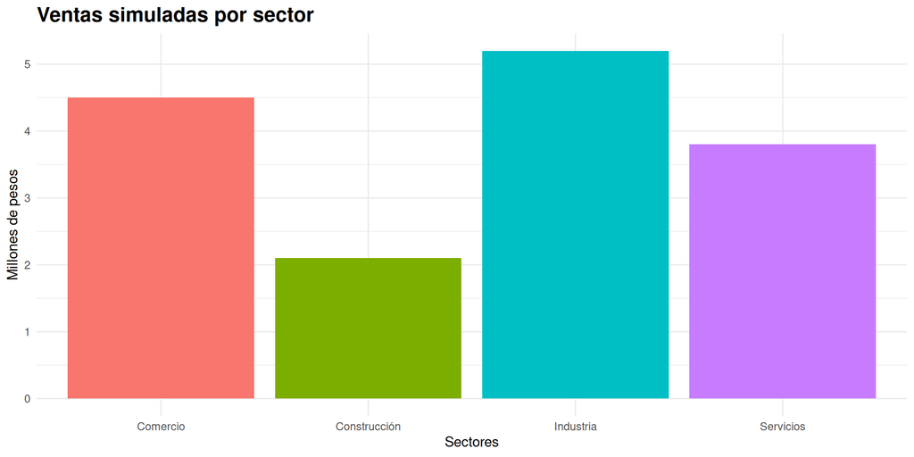

## Histograma

- Representa la distribución de una variable **cuantitativa continua** mediante barras unidas.
- Permite observar la forma de la distribución (simétrica, sesgada, etc.) y ver que intervalo o categoría tiene mayor frecuencia.
- **Ejemplo:** Las calificaciones de 10 estudiantes en un examen final fueron 60, 62, 65, 70, 72, 75, 78, 80, 85, 90.

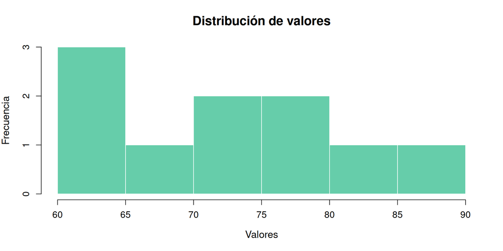

## Polígono de frecuencias

[figure not shown]

## Gráfico circular (pie plot)

- Muestra proporciones o porcentajes de un total.
- Permite identificar qué categoría tiene mayor participación.
- **Ejemplo:** Composición del gasto del hogar

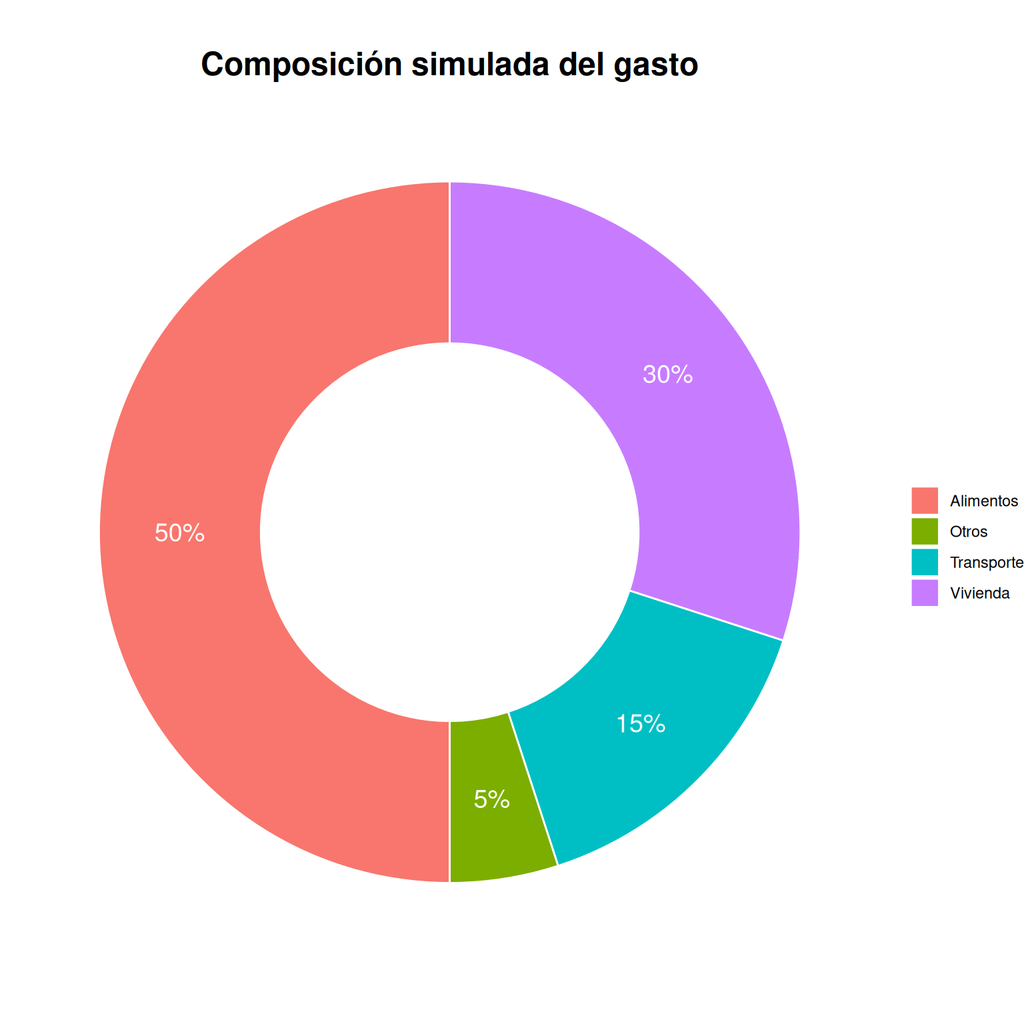

## Gráfico de líneas

- Se usa para mostrar tendencias a lo largo del tiempo.
- Permite observar aumentos y disminuciones
- **Ejemplo:** Índice de precios anual.

[figure not shown]

## Conclusión

Las gráficas, tanto en **contextos generales** como en las ciencias económicas, **permiten** analizar datos de manera visual, **identificar patrones importantes** y apoyar la toma de decisiones en procesos productivos y científicos.

## ¿Cómo interpretar una gráfica?

- Identificar la forma de la distribución.
- Observar dónde se concentran los datos.
- Detectar simetría o asimetría.
- Analizar valores extremos.
- Relacionar con el contexto del problema.

## Distribuciones

## Tipos de distribuciones

### Distribución simétrica

- **Características:**
- Forma de “campana”.
- Media ≈ mediana ≈ moda.
- Igual comportamiento a ambos lados.
- **Ejemplo:** Se mide la precio (en miles de pesos) de 100 productos comparables en un mercado simulado.

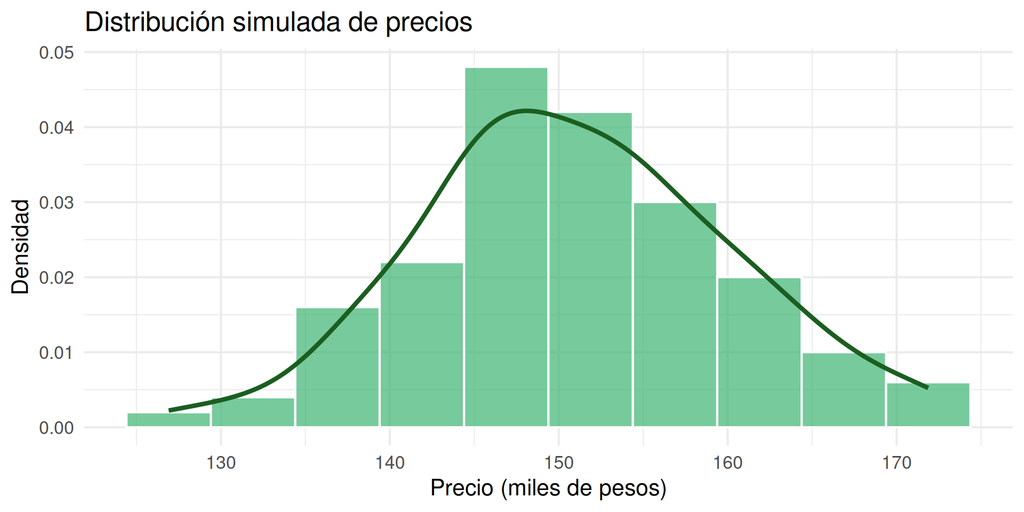

## Interpretación

- La mayoría de los productos tiene precios cercanos a 150 mil pesos.
- La distribución es simétrica, indicando precios relativamente homogéneos.
- Hay pocos productos con precios muy bajos o muy altos.
- En estos datos simulados, los precios presentan dispersión moderada.

## Tipos de distribuciones

### Distribución asimétrica positiva

Los datos se concentran en las primeras categorías (valores bajos) y hay una “cola” hacia la derecha.

- **Características:**
- Cola hacia valores altos
- Media > mediana.
- Pocos valores grandes influyen en el promedio.
- **Ejemplo:** Ingresos simulados de una muestra de hogares.

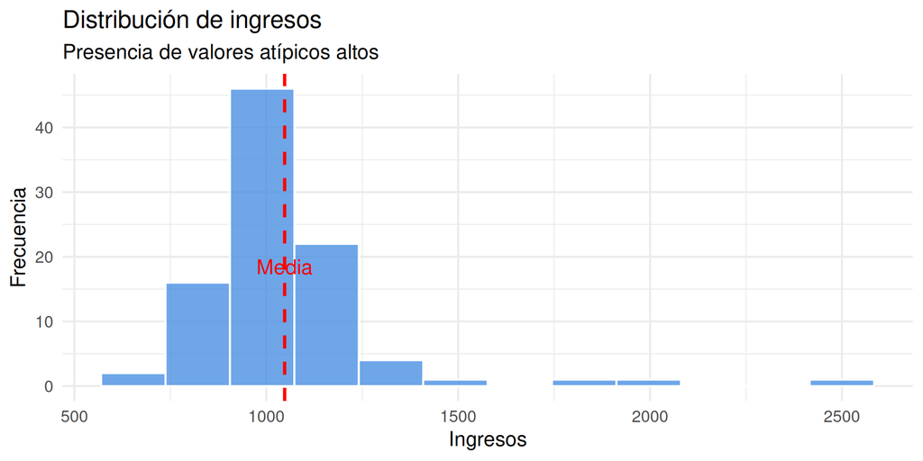

## Interpretación

- La mayoría de los datos se concentra en valores bajos y medios.
- Los valores disminuyen gradualmente hacia la derecha.
- Se observa una cola hacia la derecha.
- La distribución presenta asimetría positiva.

## Tipos de distribuciones

### Distribución asimétrica negativa

La asimetría negativa ocurre cuando los datos se concentran en valores altos y presentan una cola hacia los valores bajos.

- **Características:**
- La cola se extiende hacia la izquierda.
- Media < mediana.
- Existen pocos valores bajos que afectan la distribución.
- **Ejemplo:** Ventas mensuales (millones de pesos), donde la mayoría de las unidades presenta valores altos, pero algunas registran valores bajos.

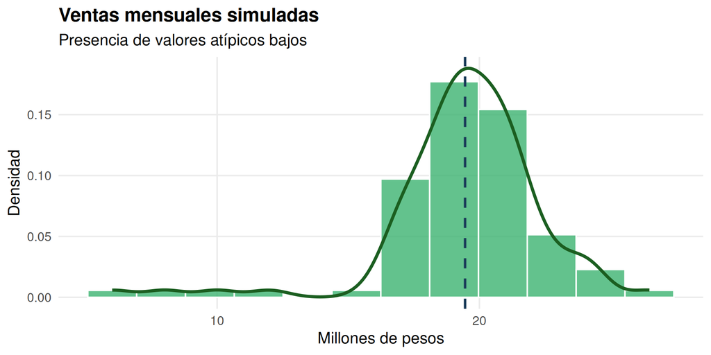

## Interpretación

- La mayoría de los valores se concentra en ventas altas.
- Existen pocos valores bajos que generan una cola hacia la izquierda.
- La distribución presenta asimetría negativa.
- El gráfico indica que la mayoría de las unidades presenta ventas altas, pero en algunos casos presentan bajo desempeño.

## Conclusiones presentación gráfica

La forma de una gráfica permite entender cómo se comportan los datos, identificar posibles problemas (valores atípicos) y tomar decisiones más informadas, especialmente en áreas como la economía donde la variabilidad es clave.

## Conclusiones finales presentación tabular y gráfica

- La presentación tabular permite organizar los datos de manera estructurada, facilitando su lectura y análisis detallado.
- La presentación gráfica complementa las tablas al representar la información de forma visual, permitiendo identificar patrones, tendencias y comportamientos de manera rápida.
- El uso conjunto de tablas y gráficas mejora la comprensión de los datos y facilita la interpretación de la información.
- Las gráficas permiten detectar características importantes como la simetría, la asimetría y la presencia de valores atípicos.
- Una adecuada presentación de los datos es fundamental para apoyar la toma de decisiones en diferentes áreas, como la economía y otras disciplinas.

## Ejercicio

Se registró el **gasto mensual en alimentos (miles de pesos)** en 30 hogares seleccionadas aleatoriamente en un ensayo experimental:

[output not shown]

#### Con los datos anteriores:

1. Determinar el número de clases $k$ usando la fórmula de Sturges y la raíz cuadrada de $n$.
2. Calcular el rango $R$, la amplitud $A$ y construir los intervalos.
3. Elaborar la tabla de frecuencias completa con $x_i$, $f_i$, $F_i$, $h_i$, $H_i$ y %.
4. Construir el histograma de frecuencias absolutas.